# writeup

#’ A single play of the Martingale strategy #’ This type of system is based on the idea that you will double your bet after losing trades and—in theory—you will always cover your losses with winning bets that are double the amount of the losing bet. #’ #’ Takes a state list, spins the roulette wheel, returns the state list with updated values (for example, budget, plays, etc) #’ @param state A list with the following entries: #’ B number, the budget #’ W number, the budget threshold for successfully stoping #’ L number, the maximum number of plays #’ M number, the casino wager limit #’ plays integer, the number of plays executed #’ previous_wager number, the wager in the previous play (0 at first play) #’ previous_win TRUE/FALSE, indicator if the previous play was a win (TRUE at first play) #’ @return The updated state list

```r
library(dplyr)
```

```r
library(ggplot2)
one_play <- function(state){

    # Wager
    proposed_wager <- ifelse(state$previous_win, 1, 2*state$previous_wager)
    wager <- min(proposed_wager, state$M, state$B)

    # Spin of the wheel
    red <- rbinom(1,1,18/38)

    # Update state
    state$plays <- state$plays + 1
    state$previous_wager <- wager
    if(red){
      # WIN
      state$B <- state$B + wager
      state$previous_win <- TRUE
    }else{
      # LOSE
      state$B <- state$B - wager
      state$previous_win <- FALSE
    }
  state
}
```

#’ Stopping rule #’ #’ Takes the state list and determines if the gambler has to stop #’ @param state A list. See one_play #’ @return TRUE/FALSE

```r
stop_play <- function(state){
  if(state$B <= 0) return(TRUE)
  if(state$plays >= state$L) return(TRUE)
  if(state$B >= state$W) return(TRUE)
  FALSE
}
```

#’ Play roulette to either bankruptcy, success, or play limits #’ #’ @param B number, the starting budget #’ @param W number, the budget threshold for successfully stoping #’ @param L number, the maximum number of plays #’ @param M number, the casino wager limit #’ @return A vector of budget values calculated after each play.

```r
one_series <- function(
    B = 200
  , W = 300
  , L = 1000
  , M = 100
){

  # initial state
  state <- list(
    B = B
  , W = W
  , L = L
  , M = M
  , plays = 0
  , previous_wager = 0
  , previous_win = TRUE
  )

  # vector to store budget over series of plays
  budget <- rep(NA, L)

  # For loop of plays
  for(i in 1:L){
    new_state <- state %>% one_play
    budget[i] <- new_state$B
    if(new_state %>% stop_play){
      return(budget[1:i])
    }
    state <- new_state
  }
  budget
}
```

# helper function

```r
get_last <- function(x) x[length(x)]
```

# Simulation

```r
walk_out_money <- rep(NA, 10000)
for(j in seq_along(walk_out_money)){
  walk_out_money[j] <- one_series(B = 200, W = 300, L = 1000, M = 100) %>% get_last
}
```

# Walk out money distribution

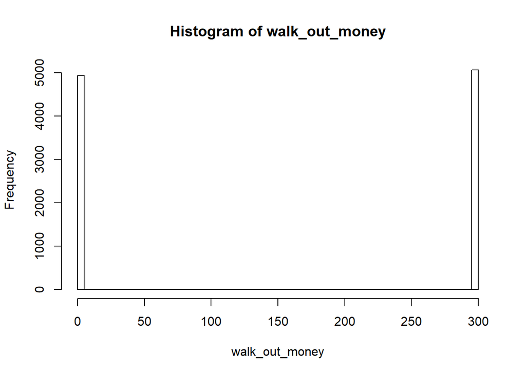

```r
hist(walk_out_money, breaks = 100)
```

# Estimated probability of walking out with extra cash

```r
mean(walk_out_money > 200)
```

```
## [1] 0.5063
```

# Estimated earnings

```r
mean(walk_out_money - 200)
```

```
## [1] -48.0845
```

# Average earnings of a gambler that uses this strategy?

# By repeating the process, we could estimate the operating characteristics for simulating distribution. We sum the value of walk out money and divide maximum number of plays to receive the average earnings.

```r
average_earnings <- sum(one_series()-200)/1000
```

[output not shown]

# provide a figure (or a series of figures) that show how the gamblers earnings (or losses) evolve over a series of wagers at the roulette wheel?

# The x-axis will be the wager number (or play number), the y-axis will be earnings.

# We could see that in one specific series, before the gambler stops, we can reach the winnings threshold in a long run. Some outliers do exist.

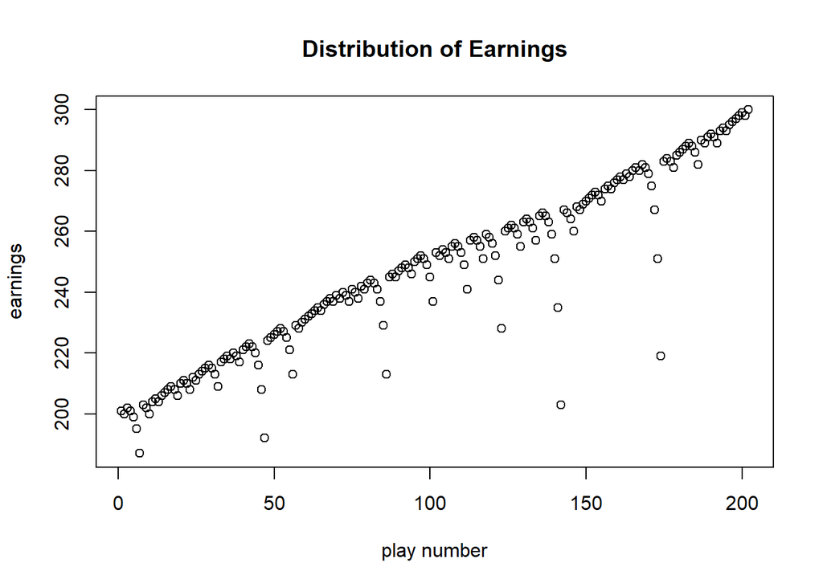

```r
plot(one_series(), main=paste("Distribution of Earnings"), xlab="play number", ylab="earnings")
```

# how changing a parameter of the simulation (see table below) does or does not have an impact on average earnings?

# We can try to change W from 300 to 500.

```r
one_series_change <- function(
    B = 200
  , W = 500
  , L = 1000
  , M = 100
){

  # initial state
  state <- list(
    B = B
  , W = W
  , L = L
  , M = M
  , plays = 0
  , previous_wager = 0
  , previous_win = TRUE
  )

  # vector to store budget over series of plays
  budget <- rep(NA, L)

  # For loop of plays
  for(i in 1:L){
    new_state <- state %>% one_play
    budget[i] <- new_state$B
    if(new_state %>% stop_play){
      return(budget[1:i])
    }
    state <- new_state
  }
  budget
}
a <- one_series_change()
average_earnings_change <- sum(a-200)/1000
```

[output not shown]